# Getting Started with EZEC

Zhian N. Kamvar

2016-12-04

# Welcome

## Introduction

The package EZEC stands for Easy Effective Concentration. This package was designed to be a simple wrapper for the functions `drm()` and `ED()` in the [*drc*](https://cran.r-project.org/package=drc) package. It provides the function `EC_table()` that will first fit a model to your data and then calculate effective concentrations from that model over several samples arranged in a data frame. In this tutorial, I will give a couple of short examples of how you can analyze your data. To get help with any functions in the package, simply type `help("function.name")` and replace function.name with the name of the function you want help for.

## Credit

As this package is simply a wrapper to two functions from the *drc* package, please cite the drc package and indicate the version number you used:

```r
packageVersion("drc")
```

```
## [1] '2.5.12'
```

```r
citation("drc")
```

```
##
##
##   Ritz, C. & Streibig, J. C. (2005) Bioassay Analysis using R. J.
##   Statist. Software, Vol 12, Issue 5.
##
## A BibTeX entry for LaTeX users is
##
##   @Article{,
##     title = {Bioassay Analysis using R},
##     author = {C. Ritz and J. C. Streibig},
##     journal = {Journal of Statistical Software},
##     volume = {12},
##     issue = {5},
##     year = {2005},
##     url = {http://www.bioassay.dk},
##   }
```

# Data Format

Your data must be in a format that encodes one observation per row. You can see an example of this in the `dummydata` data set:

```r
library("ezec")
data("dummydata", package = "ezec")
head(dummydata) # the function head means "look at the top of the object"
```

```
##        ID strain      fung dose rep response
## 1 Sample1      a Metalaxyl  0.0   1      1.5
## 2 Sample1      a Metalaxyl  0.0   2      1.0
## 3 Sample1      a Metalaxyl  0.1   1      0.5
## 4 Sample1      a Metalaxyl  0.1   2      1.0
## 5 Sample1      a Metalaxyl  1.0   1      0.5
## 6 Sample1      a Metalaxyl  1.0   2      0.5
```

You can see that this contains the columns ID, strain, fung, dose, rep, response. The only important columns here are the **ID**, **dose**, and **response** columns.

To import your own data from csv text file, you should use the function `read.table()` to import it into R. If you want to import data from an xlsx file, you can use the function `read_excel()` from the *readxl* package.

# Data Analysis

You can analyze your data simply by running `EC_table()` with your data and supplying a formula to describe what you want to analyze in the form of `response_variable ~ explanitory_variable`. In our example of “dummydata”, our response variable is “response” and our explanitory variable is “dose”.

```r
library("ezec")
data("dummydata", package = "ezec")
res <- EC_table(dummydata, form = response ~ dose)
```

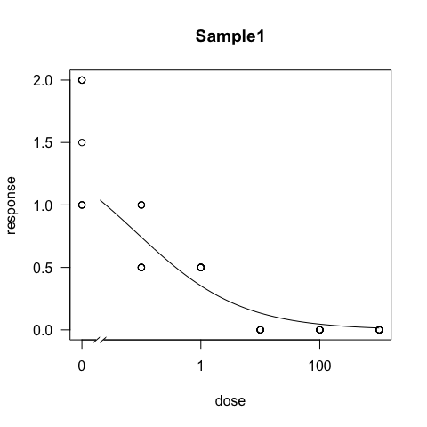

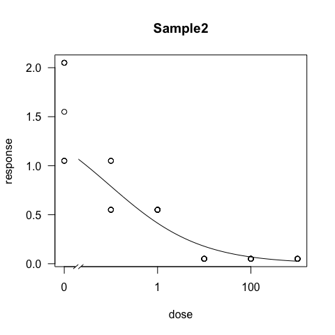

```r
print(res)
```

```
## # A tibble: 2 × 7
##    sample  Estimate.10        SE.10 Estimate.50      SE.50 Estimate.90
##     <chr>        <dbl>        <dbl>       <dbl>      <dbl>       <dbl>
## 1 Sample1 0.0009539812 0.0011786368  0.08287674 0.04098527    7.199884
## 2 Sample2 0.0006601386 0.0008750109  0.09240879 0.04713886   12.935744
## # ... with 1 more variables: SE.90 <dbl>
```

If you want to have all the plots plotted in one window, you can use the `par()` function:

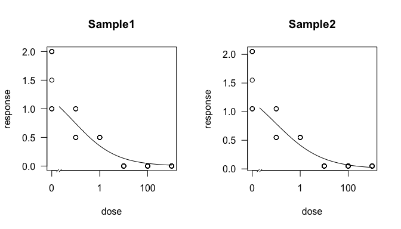

```
## # A tibble: 2 × 7
##    sample  Estimate.10        SE.10 Estimate.50      SE.50 Estimate.90
##     <chr>        <dbl>        <dbl>       <dbl>      <dbl>       <dbl>
## 1 Sample1 0.0009539812 0.0011786368  0.08287674 0.04098527    7.199884
## 2 Sample2 0.0006601386 0.0008750109  0.09240879 0.04713886   12.935744
## # ... with 1 more variables: SE.90 <dbl>
```

```r
par(mfrow = c(1, 2)) # set window to have 1 row and two columns
EC_table(dummydata, form = response ~ dose)
```

```r
par(mfrow = c(1, 1)) # reset the window
```

## Saving your results to a file

If you want to save your results to a file that you can format for a manuscript, you can use the `write.table()` functon:

```r
write.table(res, file = "dummy_results.csv", row.names = FALSE, sep = ",")
```

## Output: model summary

You can also have the output be a summary of the model for each sample as a list

```r
EC_table(dummydata, form = response ~ dose, plot = FALSE, result = "summary")
```

```
## $Sample1
##
## Model fitted: Log-logistic (ED50 as parameter) with lower limit at 0 (3 parms)
##
## Parameter estimates:
##
##                          Estimate Std. Error   t-value p-value
## Slope:(Intercept)        0.492158   0.096463  5.102022  0.0000
## Upper Limit:(Intercept)  1.556544   0.084577 18.403838  0.0000
## ED50:(Intercept)         0.082877   0.040985  2.022111  0.0491
##
## Residual standard error:
##
##  0.2379276 (45 degrees of freedom)
##
## $Sample2
##
## Model fitted: Log-logistic (ED50 as parameter) with lower limit at 0 (3 parms)
##
## Parameter estimates:
##
##                          Estimate Std. Error   t-value p-value
## Slope:(Intercept)        0.444645   0.085522  5.199200  0.0000
## Upper Limit:(Intercept)  1.607358   0.083651 19.215124  0.0000
## ED50:(Intercept)         0.092409   0.047139  1.960353  0.0562
##
## Residual standard error:
##
##  0.2355344 (45 degrees of freedom)
```

## Output: model

You can also choose to have the output be the model itself

```r
EC_table(dummydata, form = response ~ dose, plot = FALSE, result = "model")
```

```
## $Sample1
##
## A 'drc' model.
##
## Call:
## drc::drm(formula = form, data = x, fct = MODEL(names = mod.names),     na.action = na.omit)
##
## Coefficients:
##       Slope:(Intercept)  Upper Limit:(Intercept)         ED50:(Intercept)
##                 0.49216                  1.55654                  0.08288
##
##
## $Sample2
##
## A 'drc' model.
##
## Call:
## drc::drm(formula = form, data = x, fct = MODEL(names = mod.names),     na.action = na.omit)
##
## Coefficients:
##       Slope:(Intercept)  Upper Limit:(Intercept)         ED50:(Intercept)
##                 0.44464                  1.60736                  0.09241
```